# Part I - (PISA 2012 Survey)

## Introduction

> The dataset contains features that measure the knowledge, confidence and interest of students on different subjects such as math and science and provides background information on the students from 65 different economies.

## Preliminary Wrangling

```python
# import all packages and set plots to be embedded inline
import numpy as np
import pandas as pd
import matplotlib.pyplot as plt
import seaborn as sb

%matplotlib inline
```

```python
df = pd.read_csv("pisa2012.csv", encoding="ISO-8859-1")
```

### What is the structure of your dataset?

> Close to a 500k records/observations(rows) and 636 features(columns)

### What is/are the main feature(s) of interest in your dataset?

> There are about 190 features of interest that drive my research questions, some of which:
> - Math Interest
> - Subjective Norms
> - Math Self-Efficacy
> - Attributions to Failure

```python
# Creating a copy of the original dataset
df_act = df.copy()
```

> Based on the pisadict2012.csv file for description of features in pisa2012.csv, I created a file named INTERESTED.csv to store the features that I chose for my analysis and their corresponding descriptions

```python
# Importing file for features of interest
des = pd.read_csv("INTERESTED.csv")
des = des.rename(columns={"Unnamed: 0":"features", "x":"description"})
```

```python
# Getting features as an array
to_keep = des["features"].values

# Creating a revised dataframe
df_act = df_act.loc[:, to_keep]

# Saving the revised dataframe for later access and faster reading speed
df_act.to_csv("selected_features.csv", index=False)
```

```python
# Importing the revised dataset
df_act = pd.read_csv("selected_features.csv")
```

## Assessing Data

```python
df_act.head()
```

|  | CNT | SUBNATIO | STRATUM | OECD | NC | SCHOOLID | STIDSTD | ST01Q01 | ST02Q01 | ST03Q01 | ... | ST94Q14 | IC01Q01 | IC01Q02 | IC01Q03 | IC01Q04 | IC01Q05 | IC01Q06 | IC01Q07 | EC01Q01 | EC02Q01 |
| --- | --- | --- | --- | --- | --- | --- | --- | --- | --- | --- | --- | --- | --- | --- | --- | --- | --- | --- | --- | --- | --- |
| 0 | Albania | 80000 | ALB0006 | Non-OECD | Albania | 1 | 1 | 10 | 1.0 | 2 | ... | Somewhat like me | NaN | NaN | NaN | NaN | NaN | NaN | NaN | NaN | NaN |
| 1 | Albania | 80000 | ALB0006 | Non-OECD | Albania | 1 | 2 | 10 | 1.0 | 2 | ... | Not much like me | NaN | NaN | NaN | NaN | NaN | NaN | NaN | NaN | NaN |
| 2 | Albania | 80000 | ALB0006 | Non-OECD | Albania | 1 | 3 | 9 | 1.0 | 9 | ... | Very much like me | NaN | NaN | NaN | NaN | NaN | NaN | NaN | NaN | NaN |
| 3 | Albania | 80000 | ALB0006 | Non-OECD | Albania | 1 | 4 | 9 | 1.0 | 8 | ... | NaN | NaN | NaN | NaN | NaN | NaN | NaN | NaN | NaN | NaN |
| 4 | Albania | 80000 | ALB0006 | Non-OECD | Albania | 1 | 5 | 9 | 1.0 | 10 | ... | Mostly like me | NaN | NaN | NaN | NaN | NaN | NaN | NaN | NaN | NaN |

5 rows × 198 columns

```python
# Displaying number of missing values, proportional to the total size of the dataset
df_act.isnull().sum() / df_act.shape[0]
```

```
CNT         0.000000
SUBNATIO    0.000000
STRATUM     0.000000
OECD        0.000000
NC          0.000000
              ...
IC01Q05     0.389098
IC01Q06     0.392834
IC01Q07     0.390068
EC01Q01     0.678587
EC02Q01     0.678659
Length: 198, dtype: float64
```

```python
# drop the last two columns with approximately 68% missing values
df_act = df_act.drop(["EC02Q01", "EC01Q01"], axis=1)
```

```python
# Displaying numeric-only columns
df_act.select_dtypes(include='number')
```

|  | SUBNATIO | SCHOOLID | STIDSTD | ST01Q01 | ST02Q01 | ST03Q01 | ST03Q02 | ST06Q01 | ST115Q01 | ST26Q15 | ST26Q16 | ST26Q17 | ST57Q01 | ST57Q02 | ST57Q03 | ST57Q04 | ST57Q05 | ST57Q06 |
| --- | --- | --- | --- | --- | --- | --- | --- | --- | --- | --- | --- | --- | --- | --- | --- | --- | --- | --- |
| 0 | 80000 | 1 | 1 | 10 | 1.0 | 2 | 1996 | 6.0 | 1.0 | 8002 | 8001 | 8002 | NaN | NaN | NaN | NaN | NaN | NaN |
| 1 | 80000 | 1 | 2 | 10 | 1.0 | 2 | 1996 | 7.0 | 1.0 | 8001 | 8001 | 8002 | NaN | NaN | 6.0 | 0.0 | 0.0 | 2.0 |
| 2 | 80000 | 1 | 3 | 9 | 1.0 | 9 | 1996 | 6.0 | 1.0 | 8001 | 8001 | 8001 | NaN | 6.0 | 6.0 | 7.0 | 2.0 | 3.0 |
| 3 | 80000 | 1 | 4 | 9 | 1.0 | 8 | 1996 | 6.0 | 1.0 | 8001 | 8001 | 8002 | 10.0 | 2.0 | 2.0 | 0.0 | 0.0 | 3.0 |
| 4 | 80000 | 1 | 5 | 9 | 1.0 | 10 | 1996 | 6.0 | 2.0 | 8001 | 8002 | 8001 | NaN | NaN | NaN | NaN | NaN | NaN |
| ... | ... | ... | ... | ... | ... | ... | ... | ... | ... | ... | ... | ... | ... | ... | ... | ... | ... | ... |
| 485485 | 7040000 | 162 | 4955 | 10 | 3.0 | 6 | 1996 | 6.0 | 1.0 | 704002 | 704001 | 704002 | 5.0 | NaN | 0.0 | 0.0 | 0.0 | 3.0 |
| 485486 | 7040000 | 162 | 4956 | 10 | 3.0 | 2 | 1996 | 6.0 | 1.0 | 704002 | 704001 | 704002 | NaN | NaN | NaN | NaN | NaN | NaN |
| 485487 | 7040000 | 162 | 4957 | 10 | 3.0 | 6 | 1996 | 6.0 | 1.0 | 704002 | 704001 | 704002 | NaN | NaN | NaN | NaN | NaN | NaN |
| 485488 | 7040000 | 162 | 4958 | 10 | 3.0 | 6 | 1996 | 6.0 | 1.0 | 704002 | 704001 | 704002 | 4.0 | 4.0 | 0.0 | 0.0 | 0.0 | 5.0 |
| 485489 | 7040000 | 162 | 4959 | 10 | 3.0 | 12 | 1996 | 6.0 | 1.0 | 9999999 | 704001 | 9999999 | 6.0 | NaN | 0.0 | 15.0 | 0.0 | 0.0 |

485490 rows × 18 columns

> judging from the table of numerical columns above, this particular dataset seem to be categorical-centric and that numerical features would less likely contribute to discovering interesting insights.

However, the following two features could be beneficial and worth giving them more descriptive names.

Renaming the following numerical columns:

- ST03Q02: Birth -Year
- ST03Q01: Birth - Month

```python
df_act = df_act.rename(columns={"ST03Q02": "YOB", "ST03Q01": "MOB"})
```

## Univariate Exploration

### Research Question #1:

> Exploring the effect of Subjective Norms on Math Interest and Math Self-Efficacy.

#### Features relevant to the queation

First feature category: Mathematics interest (INTMAT)

- ST29Q01: Math Interest - Enjoy Reading
- ST29Q03: Math Interest - Look Forward to Lessons
- ST29Q04: Math Interest - Enjoy Maths
- ST29Q06: Math Interest - Interested

Second feature category: Subjective norms in mathematics (SUBNORM)

- ST35Q01: Subjective Norms -Friends Do Well in Mathematics
- ST35Q02: Subjective Norms -Friends Work Hard on Mathematics
- ST35Q03: Subjective Norms - Friends Enjoy Mathematics Tests
- ST35Q04: Subjective Norms - Parents Believe Studying Mathematics Is Important
- ST35Q05: Subjective Norms - Parents Believe Mathematics Is Important for Career
- ST35Q06: Subjective Norms - Parents Like Mathematics

Third feature category: Mathematics self-efficacy (MATHEFF)

- ST37Q02: Math Self-Efficacy - Calculating TV Discount
- ST37Q03: Math Self-Efficacy - Calculating Square Metres of Tiles
- ST37Q04: Math Self-Efficacy - Understanding Graphs in Newspapers
- ST37Q05: Math Self-Efficacy - Solving Equation 1
- ST37Q06: Math Self-Efficacy - Distance to Scale
- ST37Q07: Math Self-Efficacy - Solving Equation 2
- ST37Q08: Math Self-Efficacy - Calculate Petrol Consumption Rate

Fourth feature category: Mathematics self-concept (SCMAT)

- ST42Q02: Math Self-Concept - Not Good at Maths
- ST42Q04: Math Self-Concept- Get Good Grades
- ST42Q06: Math Self-Concept - Learn Quickly
- ST42Q07: Math Self-Concept - One of Best Subjects
- ST42Q09: Math Self-Concept - Understand Difficult Work

Fifth feature category: Mathematics anxiety (ANXMAT)

- ST42Q01: Math Anxiety - Worry That It Will Be Difficult
- ST42Q03: Math Anxiety - Get Very Tense
- ST42Q05: Math Anxiety - Get Very Nervous
- ST42Q08: Math Anxiety - Feel Helpless
- ST42Q10: Math Anxiety - Worry About Getting Poor Grades

```python
first_category = ["ST29Q01", "ST29Q03", "ST29Q04", "ST29Q06"]
second_category = ["ST35Q01", "ST35Q02", "ST35Q03", "ST35Q04", "ST35Q05", "ST35Q06"]
third_category = ["ST37Q02", "ST37Q03", "ST37Q04", "ST37Q05", "ST37Q06", "ST37Q07", "ST37Q08"]
fourth_category = ["ST42Q02", "ST42Q04", "ST42Q06", "ST42Q07", "ST42Q09"]
fifth_category = ["ST42Q01", "ST42Q03", "ST42Q05", "ST42Q08", "ST42Q10"]

cat_levels = [

    ["Strongly agree", "Agree", "Disagree", "Strongly disagree"],
    ["Very confident", "Confident", "Not very confident", "Not at all confident"]
]

# Function for changing the data type of specified columns
def convert_ordinal(cols, cats):
    for col in cols:
        order = pd.api.types.CategoricalDtype(ordered=True, categories=cats)
        df_act[col] = df_act[col].astype(order)


convert_ordinal(first_category, cat_levels[0])
convert_ordinal(second_category, cat_levels[0])
convert_ordinal(third_category, cat_levels[1])
convert_ordinal(fourth_category, cat_levels[0])
convert_ordinal(fifth_category, cat_levels[0])
```

```python
# Function for generating univariate bar-plots
def univar_bar(x):
    base_color = sb.color_palette()[0]
    if isinstance(x, list):
        fig, ax = plt.subplots(nrows=len(x),figsize = [8, 12])
        for i, col in enumerate(x):
            sb.countplot(data=df_act, x=col, color=base_color, ax=ax[i])
    else:
        sb.countplot(data=df_act, x=col, color=base_color)
```

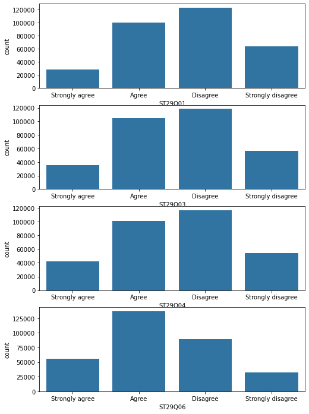

```python
univar_bar(first_category)
```

> participants seem to be teetering between agreement and disagreement regarding their interest in math across all activities(Enjoy Reading, Look Forward to Lessons, Enjoy Maths, Interested), as can be seen from the above plot.  
> Furthermore, this frequent and close ratio between agreement and disagreement implies associations with other factors rather than mere coincidence. This implied association will be investigated more in the subsequent exploration of bivariate and multivariate approaches.

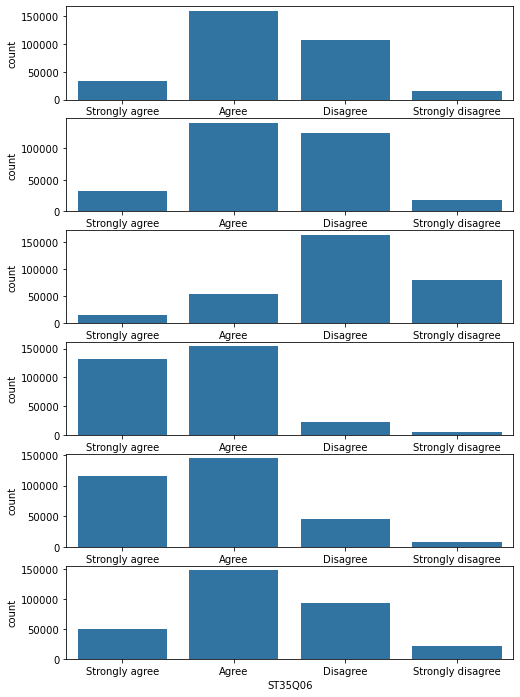

```python
univar_bar(second_category)
```

> There is a varying spectrum of opinions between agreement and disagreement, although it leans a bit more towards agreement.  
> This suggests that many students are subjected to norms regarding math and that they could be potentially influenced by their environment.  
> Parents seem to have the strongest positive influence regarding the relationship students could potentially develop for math, in contrast with friends having rather a potential negative influence on the students.  
> Given how the overall trend suggests more agreement than disagreement, but when considering the different parties involved i.e. parents (bottom three rows) vs. friends (top three rows) individually, the trend changes accordingly and could account for an instance of Simpson's Paradox.  
> However, this still does not answer my question posed at the beginning of the analysis. Considering I'm only looking at distributions of single variables, when the question asked requires associations of multiple variables.

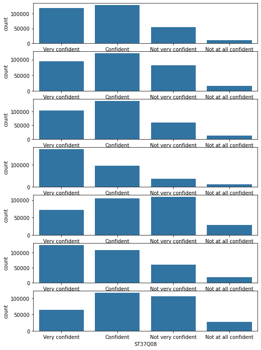

```python
univar_bar(third_category)
```

> Most students seem to be either confident or very confident about their ability to solve relatively simple math problems.

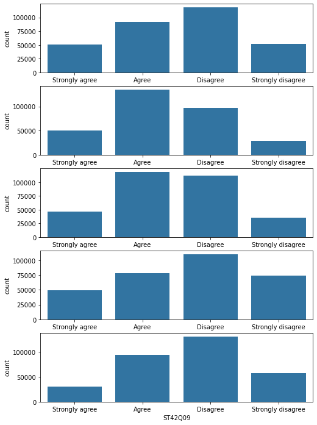

```python
univar_bar(fourth_category)
```

> There seem to be an approximately even conflict of opinions between agreement and disagreement regarding how students classify their magnitude of comprehending math-related problems.  
> This is interesting given how most students were more confident about their ability to solve math-related problems in the previous chart. This indicates that there are other factors that play into a student's overall perception of math.

## Bivariate Exploration

### Code Walkthrough:

Below I attempt to associate each level of each feature in the first category with each level of each feature in the second category. Doing so, I want to classify each student's response for each level of a feature that corresponds with a single observation to see how the different combinations form the final conclusions. And in doing so, I'm effectively increasing the size of the subset worked with exponentially. This will no longer give the count of students for a given response, but rather the number of possible combinations that constitute a certain scenario and.

Steps I followed:

- First I subset the dataset based on the two features of interest
- Then, I restructure part of the subset corresponding to one feature of interest and keeping the other feature intact
- I then restructure the second feature and keeping the newly structured feature intact, in order to account for all combination of responses.

```python
# a data subset for first and second categories
math_in = df_act.loc[:, first_category + second_category]

# First, restructuring the second category and keeping the the observations of the first category intact
math_in_melt = math_in.melt(id_vars=first_category, value_vars=second_category,
                            var_name="SUBNORM",
                            value_name="SUBNORM_RES")

# Second, restructuring the first category and keeping the observations of the second category intact
math_in_melt = math_in_melt.melt(id_vars=["SUBNORM", "SUBNORM_RES"], value_vars=first_category,
                                 var_name="INTMAT",
                                 value_name="INTMAT_RES")
```

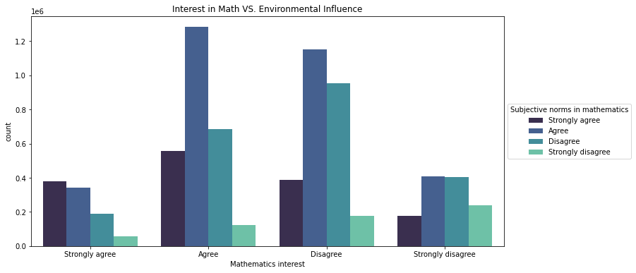

```python
plt.figure(figsize=[12, 6])

# Subsetting the various "math interest responses (x)" with "subjective norms responses (hue)"
sb.countplot(data=math_in_melt, x="INTMAT_RES", hue="SUBNORM_RES", hue_order=cat_levels[0], order=cat_levels[0],
             palette="mako")

plt.title("Interest in Math VS. Environmental Influence")
plt.xlabel("Mathematics interest")
plt.legend(title="Subjective norms in mathematics", loc = 6, bbox_to_anchor = (1.0, 0.5))

plt.show()
```

#### #1 cluster(left):

> There is an interesting consistent trend on how having a strong agreement (corresponds with strong interest across all math activities) is linearly affected by a student's environment such as their parents and friends in terms of how they perceive math and their level of comprehension or interest in the subject.

#### #2 cluster:

> The second cluster from the left represents students with less interest in math than the previous one across different environmental influences. However, there is a similar trend between a student's interest in math and these environmental influences, such as:

> ```
> - Friends Do Well in Mathematics
> - Friends Work Hard on Mathematics
> - Friends Enjoy Mathematics Tests
> - Parents Believe Studying Mathematics Is Important
> - Parents Believe Mathematics Is Important for Career
> - Parents Like Mathematics
> ```

```
Given how most students who agreed to have an interest in the different math activities also agreed to having believed that their friends and parents have an interest in math
```

#### #3 cluster:

> Here we can see that students who *disagree* on having a general interest in math come from a diverse influencing environments, mostly between *agreement* and *disagreement*. but the trend still indicates a similar pattern as before, especially if we want to consider that *agreement* alone is not a strong environmental factor concerning the subject of math.

#### #4 cluster:

> Although there are fewer students who *strongly disagree* to have an interest in math, students seem to be affected by their environment. And it's clear how the last bar in each cluster (corresponds with an eviroment with a lack of sufficient interest in math) rises consistently as you move down the scale for interest in math.

> Finally, these derived conclusions are based solely on correlations and not to be indicative of causality in that a student's environment is the *cause* for interest or lack of interest regarding math.

```python
# Here I follow the same strategy as above but with a different feature category
math_eff = df_act.loc[:, second_category + third_category]

math_eff_melt = math_eff.melt(id_vars=second_category, value_vars=third_category,
                              var_name="MATHEFF",
                              value_name="MATHEFF_RES")

math_eff_melt = math_eff_melt.melt(id_vars=["MATHEFF", "MATHEFF_RES"], value_vars=second_category,
                                   var_name="SUBNORM",
                                   value_name="SUBNORM_RES")
```

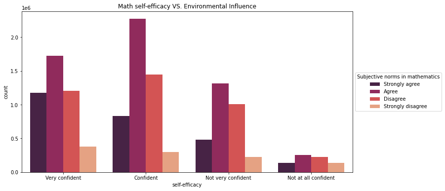

```python
plt.figure(figsize=[12, 6])

sb.countplot(data=math_eff_melt, x="MATHEFF_RES", hue="SUBNORM_RES", hue_order=cat_levels[0], order=cat_levels[1],
             palette="rocket")

plt.title("Math self-efficacy VS. Environmental Influence")
plt.xlabel("self-efficacy")
plt.legend(title="Subjective norms in mathematics", loc = 6, bbox_to_anchor = (1.0, 0.5))

plt.show()
```

#### #1 cluster(left):

> Students who have been classified as *very confident* in their overall ability to solve various math problems seem to come from various environments characterized by the level of interest in math. Since the two subjective norm rates of *strongly agree* & *agree* can add up to the most influential factor, we can assume for now that highly confident students are affected by their environment that dominintely consists of individuals with interest in math.

#### #2 cluster:

> Students classified as *confident* but not *very confident* in their overall ability to solve various math problems seem to fit the previous pattern of the correlation between environment and math interest or confidence and are in an environment dominated by *Agree* (but not *Strongly Agree*) and *Disagree* in regards to the overall perception of math.

#### remaining clusters:

> The last two clusters are similar in spirit to the second previous cluster.

### Talk about some of the relationships you observed in this part of the investigation. How did the feature(s) of interest vary with other features in the dataset?

> The features of Mathematics interest (INTMAT) and Mathematics self-efficacy (MATHEFF) although had differnet distributions they conveyed a similar pattern regarding the effect of Subjective norms in mathematics (SUBNORM) on how the students could percieve math.

### Did you observe any interesting relationships between the other features (not the main feature(s) of interest)?

> The only features used were the ones that pertained directly to the research question. However, for the purpose of detecting interaction effects between relevant features, extra features will be included in Multivariate Exploration.

## Multivariate Exploration

```python
# Choosing only one feature from some feature categories
sub = df_act.loc[:, ["ST29Q06", "ST35Q06", "ST37Q08", "ST42Q10"]]
```

```python
# Renaming columns of interest for better interpretability
sub = sub.rename(columns={"ST29Q06": "Student_Interest", "ST35Q06": "Environment_Interest", "ST37Q08": "Self_Efficacy",
                         "ST42Q10":"Math_Anxiety"})
```

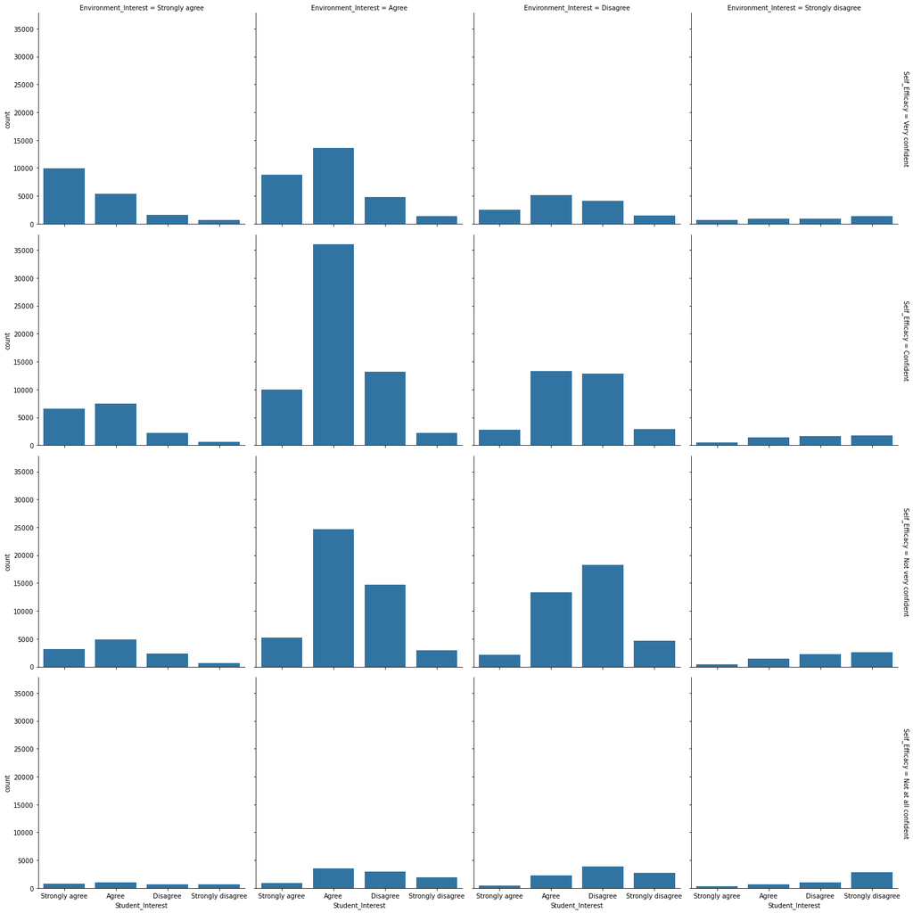

```python
# subsetting student interest by environment interest and efficacy
g = sb.FacetGrid(data=sub, col="Environment_Interest", row="Self_Efficacy", col_order=cat_levels[0],
                 height=5,
                 margin_titles=True)

g.map(sb.countplot, "Student_Interest", order=cat_levels[0])

plt.show()
```

> The second column indicates that most students with moderate interest in math are in environments with moderate interest in math as well, despite being affected by the different levels of confidence in math problem-solving. In other words, this indicates that student interest in math is influenced by their environment perception of math although they don't necessarily have to have the confidence in their ability to solve a particular math problem.

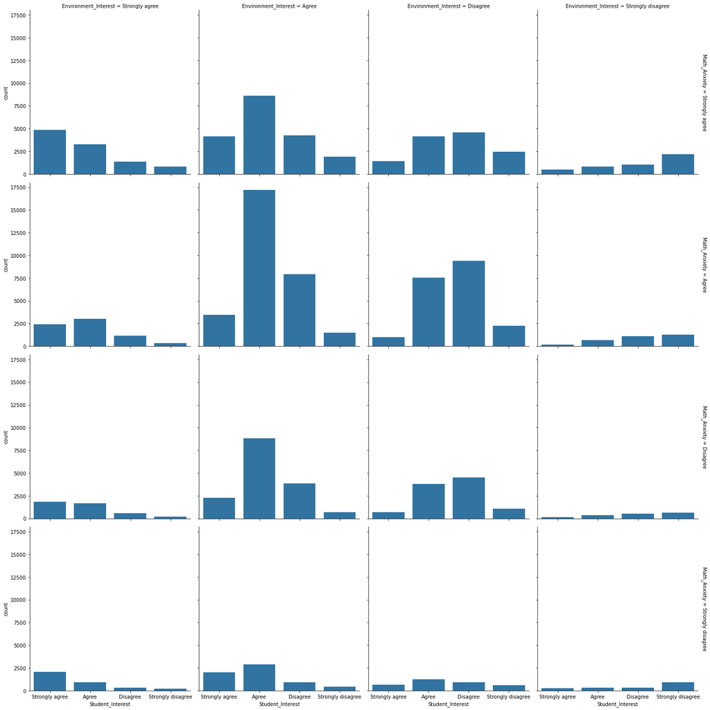

```python
g = sb.FacetGrid(data=sub, col="Environment_Interest", row="Math_Anxiety", col_order=cat_levels[0], height=5, margin_titles=True)
g.map(sb.countplot, "Student_Interest", order=cat_levels[0])

plt.show()
```

> Changing the third variable from self-efficacy to math anxiety still tells the same story, in which students' interest in math is affected by their environment, but this time, even if they measured strong level of anxiety.

### Talk about some of the relationships you observed in this part of the investigation. Were there features that strengthened each other in terms of looking at your feature(s) of interest?

> math efficacy and math anxiety seemed to strengthen the relationship between environment influence of math and students' interest. Which suggested that even in high anxiety or low confidence situations, students still had an interest in math.

### Were there any interesting or surprising interactions between features?

> There was a slight interaction in how confidence level affected the level of interest in math for a given student. Though the level of enviroment's interest had the greater effect.

## Conclusions

> There was a clear trend in how subjective norm affects a student's interest in math. This trend was less evident in the case of correlation between subjective norms and level of confidence in math for a given student. These conclusions derived from the bivariate exploration remained consistent in multivariate exploration when subjective norms had a more clear effect on interest in math than self-efficacy. The trend also remained the same when Math Anxiety was the third factor instead of self-efficacy.